# Hematopoietic Stem Cell Transplantation Outcomes Analysis

Comprehensive Analysis of OS, Mortality, and GVHD in 47 Patients

Author

Transplant Outcomes Analysis

Published

# Executive Summary

This report presents a comprehensive analysis of transplant outcomes for **47 patients** who underwent hematopoietic stem cell transplantation (HSCT). The analysis includes:

- Overall survival (OS) at 30, 100, and 365 days
- Mortality analysis: TRM, NRM, and RRM (Relapse-Related Mortality)
- Acute GVHD Grade II-IV incidence
- Chronic GVHD incidence (mild vs moderate-severe)

**Key Findings:**

- Disease status at HSCT significantly impacts survival (p=0.028)
- TRM (n=4) and NRM (n=2) together account for 67% of deaths; RRM accounts for 33% (n=3)
- All relapse deaths occurred in patients NOT in complete remission
- Haploidentical transplants associated with highest acute GVHD Grade II-IV (45%, p=0.05)
- Chronic GVHD rates similar across donor types (15-25%, p=0.857)

# Cohort Characteristics

## Patient Demographics

Cohort Summary

| Characteristic | Value |
| --- | --- |
| Total Patients | 47 |
| Median Age (range) | 60 (19-73) |
| Male/Female | 26/21 |
| Median Follow-up, days (range) | 241 (23-708) |

## Disease Status and Donor Types

Disease Status and Donor Types

| Category | Subcategory | N | Percentage |
| --- | --- | --- | --- |
| **Disease Status at HSCT** |  |  |  |
| Disease Status at HSCT | Complete Remission | 32 | 68.1 |
|  | Chronic Phase | 2 | 4.3 |
|  | MRD+ | 4 | 8.5 |
|  | Partial Remission | 2 | 4.3 |
|  | Stable Disease | 7 | 14.9 |
| **Donor Type** |  |  |  |
| Donor Type | Haploidentical | 20 | 42.6 |
|  | MUD (HLA-matched URD) | 15 | 31.9 |
|  | HLA-identical Sibling | 4 | 8.5 |
|  | Mismatched URD | 8 | 17.0 |

# Overall Survival Analysis

## Kaplan-Meier Survival Curves

### Overall Survival by Disease Status

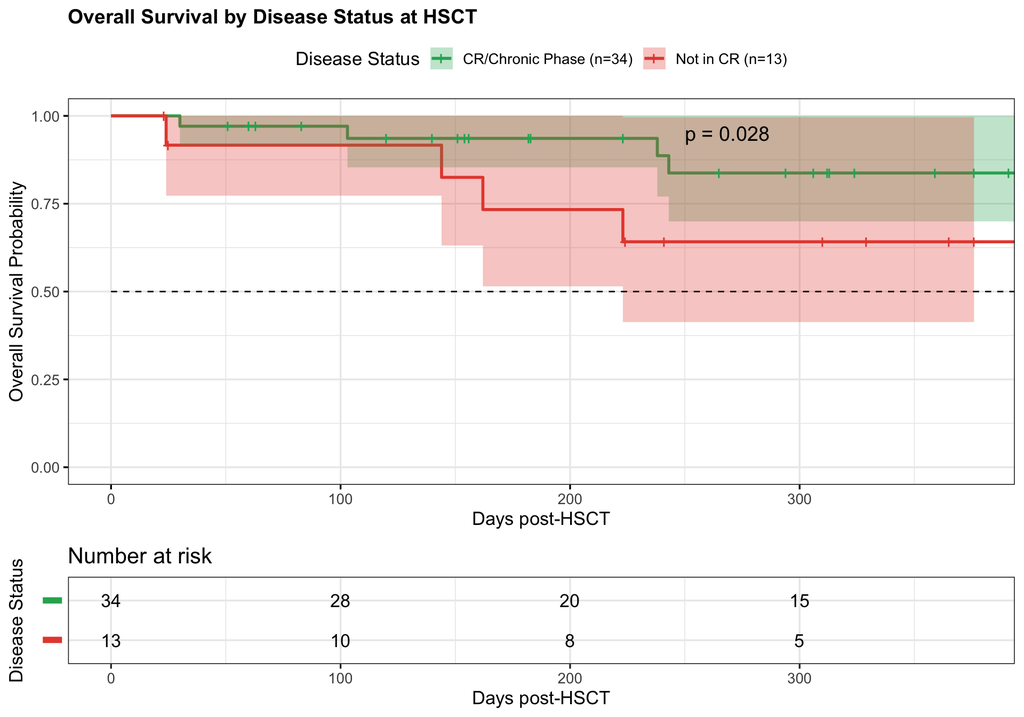

**NoteFollow-up Note**

The plot is restricted to 375 days to avoid misleading interpretation. Only 1 of 13 “Not in CR” patients has follow-up beyond 400 days, which would make survival estimates unreliable at later timepoints.

**ImportantSignificant Finding**

Disease status at HSCT is a significant predictor of overall survival (log-rank p = 0.028). Patients transplanted in CR/Chronic Phase have significantly better outcomes than those not in remission.

### Overall Survival by Donor Type (CR/Chronic Phase Patients)

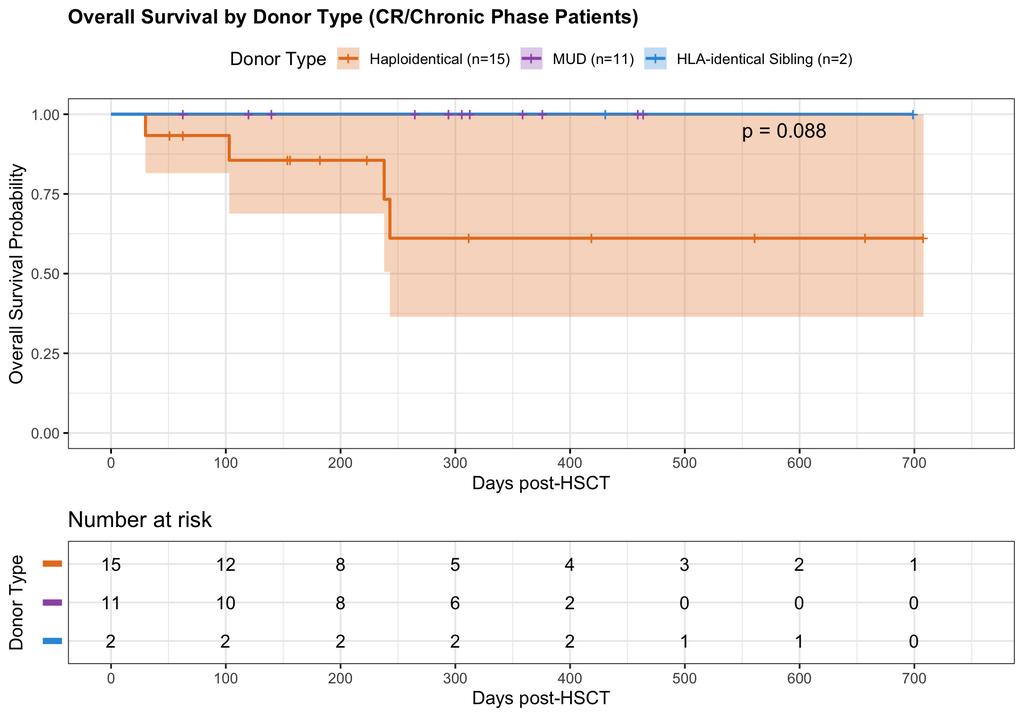

## Overall Survival at Key Timepoints

Overall Survival at 30, 100, and 365 Days

| Group | Timepoint | N Patients | Deaths | Alive | OS (%) |
| --- | --- | --- | --- | --- | --- |
| **Overall (n=47)** |  |  |  |  |  |
| Overall | 30 days | 45 | 2 | 43 | 95.6 |
| Overall | 100 days | 40 | 2 | 38 | 95.0 |
| Overall | 365 days | 21 | 8 | 13 | 61.9 |
| **CR/Chronic Phase (n=34)** |  |  |  |  |  |
| CR/Chronic Phase | 30 days | 34 | 1 | 33 | 97.1 |
| CR/Chronic Phase | 100 days | 29 | 1 | 28 | 96.6 |
| CR/Chronic Phase | 365 days | 14 | 4 | 10 | 71.4 |
| **Not in CR (n=13)** |  |  |  |  |  |
| Not in CR | 30 days | 11 | 1 | 10 | 90.9 |
| Not in CR | 100 days | 11 | 1 | 10 | 90.9 |
| Not in CR | 365 days | 7 | 4 | 3 | 42.9 |

### OS by Donor Type (CR/Chronic Phase Patients)

Overall Survival by Donor Type (CR/Chronic Phase Patients)

| Donor Type | Timepoint | OS (%) |
| --- | --- | --- |
| **HLA-identical Sibling (n=2)** |  |  |
| HLA-identical Sibling | 30 days | 100.0 |
| HLA-identical Sibling | 100 days | 100.0 |
| HLA-identical Sibling | 365 days | 100.0 |
| **Haploidentical (n=15)** |  |  |
| Haploidentical | 30 days | 93.3 |
| Haploidentical | 100 days | 92.3 |
| Haploidentical | 365 days | 50.0 |
| **MUD (n=11)** |  |  |
| MUD | 30 days | 100.0 |
| MUD | 100 days | 100.0 |
| MUD | 365 days | 100.0 |

# Mortality Analysis

## Cumulative Incidence of Competing Risks

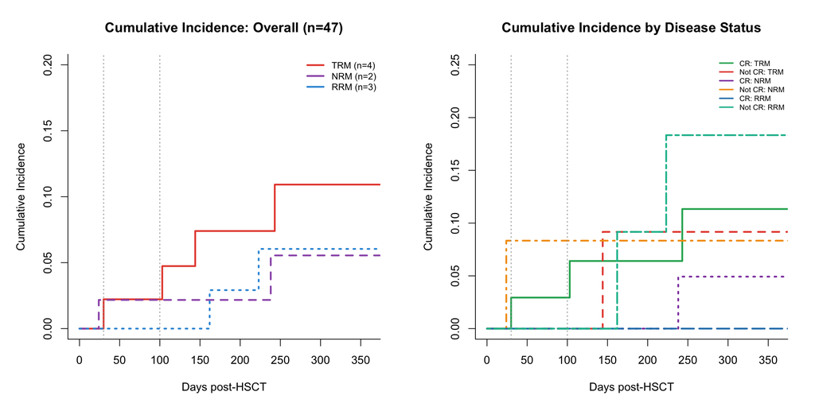

## Mortality by Type

Mortality by Type (Overall Cohort, n=47)

| Death Type | n | % |
| --- | --- | --- |
| TRM (Treatment-Related Mortality) | 4 | 8.5 |
| NRM (Non-Relapse Mortality) | 2 | 4.3 |
| RRM (Relapse-Related Mortality) | 3 | 6.4 |

**WarningImportant Finding**

All relapse-related deaths (n=3) occurred exclusively in patients who were NOT in complete remission at time of transplant. No relapse deaths were observed in CR/Chronic Phase patients.

## Causes of Death

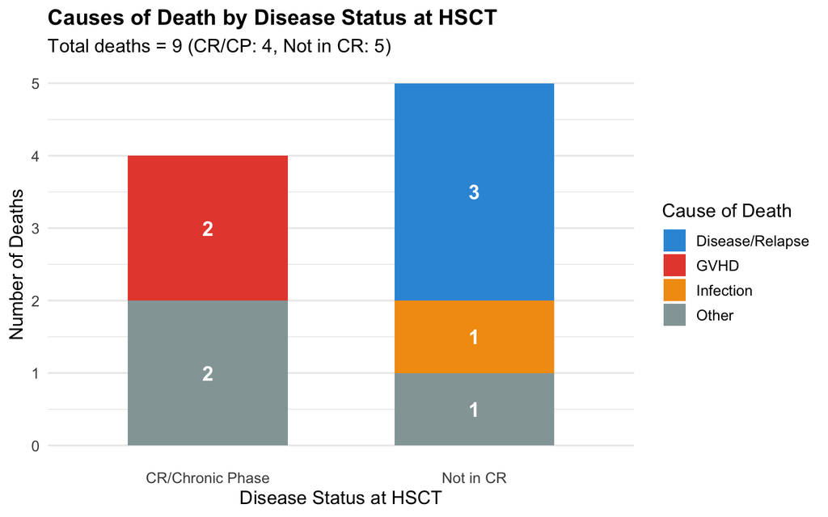

# GVHD Analysis

## Acute GVHD Grade II-IV Incidence

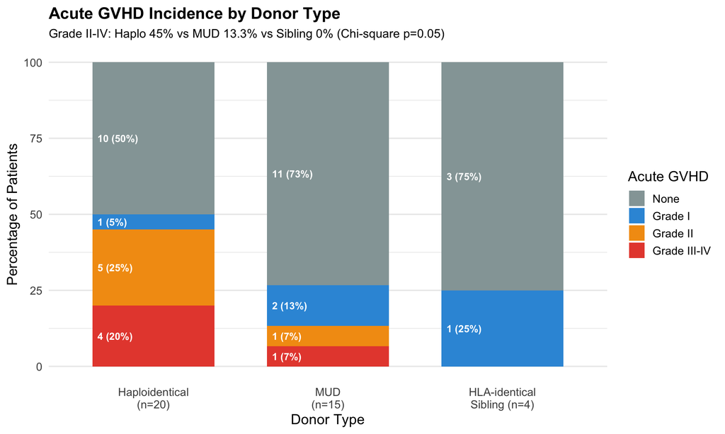

### Acute GVHD Summary Table

Acute GVHD Incidence by Donor Type

| Donor Type | N | Any Acute GVHD n | Any Acute GVHD % | Grade II-IV n | Grade II-IV % | Details Grade II | Details Grade III-IV |
| --- | --- | --- | --- | --- | --- | --- | --- |
| Haploidentical | 20 | 10 | 50.0 | 9 | 45.0 | 5 | 4 |
| MUD | 15 | 4 | 26.7 | 2 | 13.3 | 1 | 1 |
| HLA-identical Sibling | 4 | 1 | 25.0 | 0 | 0.0 | 0 | 0 |
| Overall | 47 | 17 | 36.2 | 12 | 25.5 | 6 | 6 |

**TipClinical Significance**

## Chronic GVHD Incidence

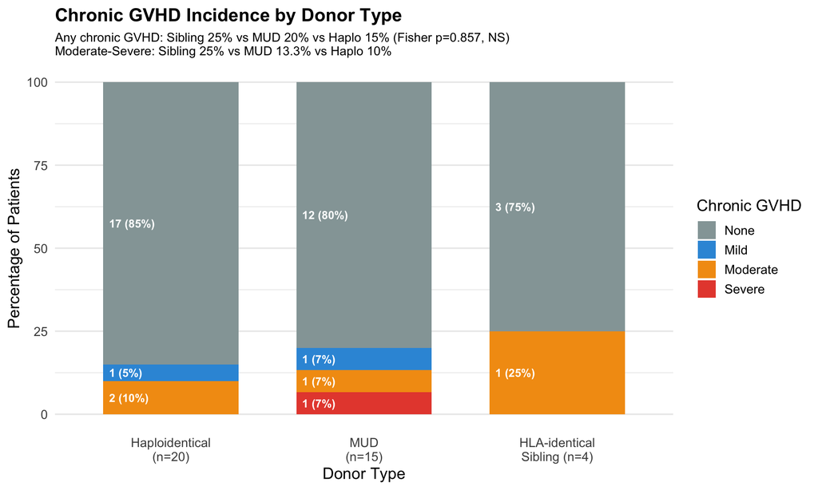

### Chronic GVHD Summary Table

Chronic GVHD Incidence by Donor Type

| Donor Type | N | Any Chronic GVHD n | Any Chronic GVHD % | Mild n | Mild % | Moderate-Severe n | Moderate-Severe % |
| --- | --- | --- | --- | --- | --- | --- | --- |
| HLA-identical Sibling | 4 | 1 | 25 | 0 | 0.0 | 1 | 25.0 |
| MUD | 15 | 3 | 20 | 1 | 6.7 | 2 | 13.3 |
| Haploidentical | 20 | 3 | 15 | 1 | 5.0 | 2 | 10.0 |
| Overall | 47 | 8 | 17 | 3 | 6.4 | 5 | 10.6 |

# Key Findings and Conclusions

## Mortality Patterns

3. **TRM and NRM are the predominant causes of death**
   - TRM: 4 deaths (44% of all deaths)
   - NRM: 2 deaths (22% of all deaths)
   - RRM (Relapse): 3 deaths (33% of all deaths)
   - Early mortality (≤100 days) exclusively due to TRM/NRM
4. **Relapse mortality only affects patients not in remission**
   - 0% relapse mortality in CR/Chronic Phase patients
   - All 3 RRM deaths occurred in patients NOT in CR at transplant

## Clinical Implications

**NoteRecommendations**

1. **Patient Selection**: Disease status at HSCT is critical - achieving CR before transplant significantly improves outcomes
2. **Donor Selection for CR Patients**:
   - MUD and sibling donors show excellent outcomes
   - Haploidentical transplants have higher GVHD rates but remain viable option
3. **GVHD Prophylaxis**: Enhanced GVHD prophylaxis strategies may be particularly important for haploidentical transplants
4. **Risk Stratification**: Patients not in CR at transplant require intensive monitoring for relapse after day 100

# Statistical Methods

## Analysis Approach

- **Survival Analysis**: Kaplan-Meier method with log-rank tests for group comparisons
- **Competing Risks**: Cumulative incidence functions for TRM, NRM, and RRM (relapse mortality)
- **Categorical Comparisons**: Chi-square and Fisher’s exact tests for GVHD incidence
- **Confidence Intervals**: 95% CI for all survival estimates
- **Statistical Significance**: p < 0.05 considered statistically significant

## Software

Analysis performed using:

- R version 4.5.1
- survival package for survival analysis
- survminer for visualization
- cmprsk for competing risks analysis
- tidyverse for data manipulation

# Data Summary

Summary of Key Outcomes (* = statistically significant)

[output not shown]

# Appendix

## Study Limitations

1. **Sample Size**: Small cohort (n=47) limits statistical power, particularly for subgroup analyses
2. **Sibling Donor Group**: Very small sample (n=4) limits interpretation
3. **Follow-up**: Variable follow-up times (median 241 days, range 23-708 days)
4. **Retrospective**: Observational nature limits causal inference

## Data Quality

- Complete data for all patients regarding survival status
- GVHD data complete for acute GVHD; chronic GVHD assessment ongoing
- All deaths were classified and adjudicated for cause

*Report generated on January 19, 2026*

*Analysis date: January 19, 2026*